# upa_analysis - draft

Peter Higgins

5/31/2022

## Let’s explore asuc

1. How many admissions - 1360
2. How many to colectomy - 513
3. ifx 110 colect, 156 not
4. cyclo 4 colect, 12 not
5. tofa 37 colect, 52 not
6. upa 7 colect, 15 not
7. steroids only 360 colect, 617 not

```r
asuc <- read_csv("Berinstein_UC_2014-2023.csv") |>
  mutate(colect = coalesce(colect, 0)) |>
  mutate(exists = 1) |>
  pivot_wider(names_from = cohort, values_from = exists, values_fill = 0) |>
  mutate(lab_value = as.numeric(lab_value))
# how many unique individual admissions
asuc |> distinct(cpi_num, admit_date) |>
  count()
```

```
## # A tibble: 1 × 1
##       n
##   <int>
## 1  1360
```

```r
# 1360
# All comers -
# how many went to colectomy? #513 yes, 847 no
asuc |> distinct(cpi_num, admit_date, .keep_all = TRUE) |>
   count(colect)
```

```
## # A tibble: 2 × 2
##   colect     n
##    <dbl> <int>
## 1      0   847
## 2      1   513
```

```r
# by group
asuc |> distinct(cpi_num, admit_date, .keep_all = TRUE) |>
  filter(ifx == 1) |>
   count(colect)
```

```
## # A tibble: 2 × 2
##   colect     n
##    <dbl> <int>
## 1      0   156
## 2      1   110
```

```r
# ifx 110 colect, 156 not
asuc |> distinct(cpi_num, admit_date, .keep_all = TRUE) |>
  filter(cyclo == 1) |>
   count(colect)
```

```
## # A tibble: 2 × 2
##   colect     n
##    <dbl> <int>
## 1      0    12
## 2      1     4
```

```r
# cyclo 4 colect, 12 not
asuc |> distinct(cpi_num, admit_date, .keep_all = TRUE) |>
  filter(tofa == 1) |>
   count(colect)
```

```
## # A tibble: 2 × 2
##   colect     n
##    <dbl> <int>
## 1      0    52
## 2      1    37
```

```r
# tofa 37 colect, 52 not
asuc |> distinct(cpi_num, admit_date, .keep_all = TRUE) |>
  filter(upa == 1) |>
   count(colect)
```

```
## # A tibble: 2 × 2
##   colect     n
##    <dbl> <int>
## 1      0    15
## 2      1     7
```

```r
# upa 7 colect, 15 not

asuc |> distinct(cpi_num, admit_date, .keep_all = TRUE) |>
  filter(steroid == 1 & ifx == 0 & cyclo == 0 & tofa == 0 & upa == 0) |>
   count(colect)
```

```
## # A tibble: 2 × 2
##   colect     n
##    <dbl> <int>
## 1      0   617
## 2      1   360
```

```r
# steroids only 360 colect, 617 not
```

Let’s look at individual therapies for FCP and CRP

Steroids only

```r
# FCP values, steroid only
asuc |>
  filter(test == "FCP") |>
   distinct(cpi_num, admit_date, .keep_all = TRUE) |>
    filter(steroid == 1 & ifx == 0 & cyclo == 0 & tofa == 0 & upa == 0) |>
  select(cpi_num ,admit_date,
         test_date, lab_value) |>
  mutate(day = as.numeric(test_date - admit_date + 1)) |>
  group_by(day) |>
  filter(day <9) |>
  summarize(mean_fcp = mean(lab_value, na.rm = TRUE),
            count = n()) |>
  gt() |>
  tab_header(title = "FCP with steroid monotherapy")
```

FCP with steroid monotherapy

| day | mean_fcp | count |
| --- | --- | --- |
| 1 | 874.090 | 10 |
| 2 | 1075.458 | 50 |
| 3 | 888.450 | 32 |
| 4 | 1050.294 | 24 |
| 5 | 740.580 | 11 |
| 6 | 72.500 | 4 |
| 7 | 1262.820 | 5 |
| 8 | 146.000 | 3 |

```r
# CRP values, steroid only
asuc |>
  filter(test == "CRP") |>    distinct(cpi_num, admit_date, .keep_all = TRUE) |>
    filter(steroid == 1 & ifx == 0 & cyclo == 0 & tofa == 0 & upa == 0) |>
  select(cpi_num ,admit_date,
         test_date, lab_value) |>
  mutate(day = as.numeric(test_date - admit_date + 1)) |>
  group_by(day) |>
  filter(day < 9) |>
  summarize(mean_crp = mean(lab_value*10, na.rm = TRUE),
            count = n()) |>
  print(n = 86) |>
  gt() |>
  tab_header(title = "CRP with steroid monotherapy")
```

```
## # A tibble: 8 × 3
##     day mean_crp count
##   <dbl>    <dbl> <int>
## 1     1     54.7   514
## 2     2     67.0   215
## 3     3     51.9    99
## 4     4     43.5    62
## 5     5     64.6    19
## 6     6     51.3    13
## 7     7     95.2     6
## 8     8     76.6     8
```

CRP with steroid monotherapy

| day | mean_crp | count |
| --- | --- | --- |
| 1 | 54.70047 | 514 |
| 2 | 67.01493 | 215 |
| 3 | 51.93548 | 99 |
| 4 | 43.50877 | 62 |
| 5 | 64.64706 | 19 |
| 6 | 51.30000 | 13 |
| 7 | 95.25000 | 6 |
| 8 | 76.60000 | 8 |

IFX treatment

```r
# FCP values, ifx only
asuc |>
  filter(test == "FCP") |>
   distinct(cpi_num, admit_date, .keep_all = TRUE) |>
    filter(ifx == 1 ) |>
  select(cpi_num ,admit_date,
         test_date, lab_value) |>
  mutate(day = as.numeric(test_date - admit_date + 1)) |>
  group_by(day) |>
  filter(day <9) |>
  summarize(mean_fcp = mean(lab_value, na.rm = TRUE),
            count = n()) |>
  gt() |>
  tab_header(title = "FCP with IFX therapy")
```

FCP with IFX therapy

| day | mean_fcp | count |
| --- | --- | --- |
| 1 | 1218.900 | 1 |
| 2 | 1643.641 | 19 |
| 3 | 1667.438 | 10 |
| 4 | 1587.567 | 9 |
| 5 | 3101.200 | 4 |
| 6 | 1409.300 | 4 |
| 7 | 1450.300 | 2 |

```r
# CRP values, ifx only
asuc |>
  filter(test == "CRP") |>    distinct(cpi_num, admit_date, .keep_all = TRUE) |>
    filter(ifx == 1 ) |>
  select(cpi_num ,admit_date,
         test_date, lab_value) |>
  mutate(day = as.numeric(test_date - admit_date + 1)) |>
  group_by(day) |>
  filter(day < 9) |>
  summarize(mean_crp = mean(lab_value*10, na.rm = TRUE),
            count = n()) |>
  print(n = 86) |>
  gt() |>
  tab_header(title = "CRP with IFX therapy")
```

```
## # A tibble: 8 × 3
##     day mean_crp count
##   <dbl>    <dbl> <int>
## 1     1     68.9   113
## 2     2     83.7    62
## 3     3     74.8    28
## 4     4     46.8    22
## 5     5     41.8    20
## 6     6     45.2    11
## 7     7      9       1
## 8     8     13       1
```

CRP with IFX therapy

| day | mean_crp | count |
| --- | --- | --- |
| 1 | 68.86792 | 113 |
| 2 | 83.68519 | 62 |
| 3 | 74.77778 | 28 |
| 4 | 46.85000 | 22 |
| 5 | 41.84211 | 20 |
| 6 | 45.22222 | 11 |
| 7 | 9.00000 | 1 |
| 8 | 13.00000 | 1 |

Cyclo treatment

```r
# FCP values, cyclo only
asuc |>
  filter(test == "FCP") |>
   distinct(cpi_num, admit_date, .keep_all = TRUE) |>
    filter(cyclo == 1 ) |>
  select(cpi_num ,admit_date,
         test_date, lab_value) |>
  mutate(day = as.numeric(test_date - admit_date + 1)) |>
  group_by(day) |>
  filter(day <9) |>
  summarize(mean_fcp = mean(lab_value, na.rm = TRUE),
            count = n()) |>
  gt() |>
  tab_header(title = "FCP with Cyclo therapy")
```

FCP with Cyclo therapy

| day | mean_fcp | count |
| --- | --- | --- |
| 2 | 2538.7 | 1 |
| 4 | 526.7 | 1 |
| 5 | 217.7 | 1 |

```r
# CRP values, cyclo only
asuc |>
  filter(test == "CRP") |>    distinct(cpi_num, admit_date, .keep_all = TRUE) |>
    filter(cyclo == 1 ) |>
  select(cpi_num ,admit_date,
         test_date, lab_value) |>
  mutate(day = as.numeric(test_date - admit_date + 1)) |>
  group_by(day) |>
  filter(day < 9) |>
  summarize(mean_crp = mean(lab_value*10, na.rm = TRUE),
            count = n()) |>
  print(n = 86) |>
  gt() |>
  tab_header(title = "CRP with Cyclo therapy")
```

```
## # A tibble: 4 × 3
##     day mean_crp count
##   <dbl>    <dbl> <int>
## 1     1       53     8
## 2     2       95     4
## 3     3       19     1
## 4     5      104     1
```

CRP with Cyclo therapy

| day | mean_crp | count |
| --- | --- | --- |
| 1 | 53 | 8 |
| 2 | 95 | 4 |
| 3 | 19 | 1 |
| 5 | 104 | 1 |

Tofa treatment

```r
# FCP values, Tofa only
asuc |>
  filter(test == "FCP") |>
   distinct(cpi_num, admit_date, .keep_all = TRUE) |>
    filter(tofa == 1 ) |>
  select(cpi_num ,admit_date,
         test_date, lab_value) |>
  mutate(day = as.numeric(test_date - admit_date + 1)) |>
  group_by(day) |>
  filter(day <9) |>
  summarize(mean_fcp = mean(lab_value, na.rm = TRUE),
            count = n()) |>
  gt() |>
  tab_header(title = "FCP with Tofa therapy")
```

FCP with Tofa therapy

| day | mean_fcp | count |
| --- | --- | --- |
| 2 | 1511.914 | 8 |
| 3 | 1342.133 | 8 |
| 4 | 1942.367 | 6 |
| 5 | 2600.400 | 3 |
| 6 | 2183.450 | 3 |
| 8 | 2700.900 | 1 |

```r
# CRP values, tofa only
asuc |>
  filter(test == "CRP") |>    distinct(cpi_num, admit_date, .keep_all = TRUE) |>
    filter(tofa == 1 ) |>
  select(cpi_num ,admit_date,
         test_date, lab_value) |>
  mutate(day = as.numeric(test_date - admit_date + 1)) |>
  group_by(day) |>
  filter(day < 9) |>
  summarize(mean_crp = mean(lab_value*10, na.rm = TRUE),
            count = n()) |>
  print(n = 86) |>
  gt() |>
  tab_header(title = "CRP with Tofa therapy")
```

```
## # A tibble: 6 × 3
##     day mean_crp count
##   <dbl>    <dbl> <int>
## 1     1     53.8    43
## 2     2     52.1    19
## 3     3     54.7    13
## 4     4     31       5
## 5     5     94       3
## 6     6     26.3     3
```

CRP with Tofa therapy

| day | mean_crp | count |
| --- | --- | --- |
| 1 | 53.82927 | 43 |
| 2 | 52.05556 | 19 |
| 3 | 54.72727 | 13 |
| 4 | 31.00000 | 5 |
| 5 | 94.00000 | 3 |
| 6 | 26.33333 | 3 |

Upa treatment

```r
# FCP values, Upa only
asuc |>
  filter(test == "FCP") |>
   distinct(cpi_num, admit_date, .keep_all = TRUE) |>
    filter(upa == 1 ) |>
  select(cpi_num ,admit_date,
         test_date, lab_value) |>
  mutate(day = as.numeric(test_date - admit_date + 1)) |>
  group_by(day) |>
  filter(day <9) |>
  summarize(mean_fcp = mean(lab_value, na.rm = TRUE),
            count = n()) |>
  gt() |>
  tab_header(title = "FCP with Upa therapy")
```

FCP with Upa therapy

| day | mean_fcp | count |
| --- | --- | --- |
| 1 | 793.00 | 1 |
| 2 | 659.95 | 5 |
| 3 | 2142.75 | 4 |
| 4 | NaN | 1 |
| 5 | 1734.80 | 3 |

```r
# CRP values, Upa only
asuc |>
  filter(test == "CRP") |>    distinct(cpi_num, admit_date, .keep_all = TRUE) |>
    filter(upa == 1 ) |>
  select(cpi_num ,admit_date,
         test_date, lab_value) |>
  mutate(day = as.numeric(test_date - admit_date + 1)) |>
  group_by(day) |>
  filter(day < 9) |>
  summarize(mean_crp = mean(lab_value*10, na.rm = TRUE),
            count = n()) |>
  print(n = 86) |>
  gt() |>
  tab_header(title = "CRP with Upa therapy")
```

```
## # A tibble: 5 × 3
##     day mean_crp count
##   <dbl>    <dbl> <int>
## 1     1     73.3     7
## 2     2     40.3     6
## 3     3    119       5
## 4     4    130       2
## 5     7     26       1
```

CRP with Upa therapy

| day | mean_crp | count |
| --- | --- | --- |
| 1 | 73.33333 | 7 |
| 2 | 40.33333 | 6 |
| 3 | 119.00000 | 5 |
| 4 | 130.00000 | 2 |
| 7 | 26.00000 | 1 |

## When does colectomy occur?

Let’s see when colectomies occur. Are some treatments just delaying colectomy?

## Retry with Beeswarm

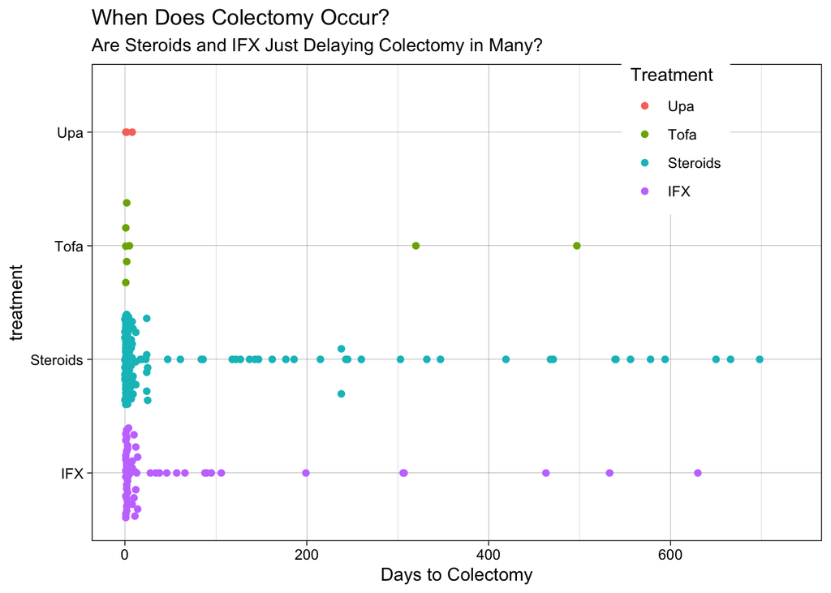

```r
library(ggbeeswarm)
asuc |>
  filter(colect == 1) |>
  mutate(cohort = factor(case_when(
    ifx == 1 ~ "IFX",
    tofa == 1 ~ "Tofa",
    upa == 1 ~ "Upa",
    .default = "Steroids"
  ), levels = rev(c("Upa", "Tofa", "Cyclo", "Steroids", "IFX")))
  )  |> distinct(cpi_num, .keep_all = TRUE) |>
  ggplot(aes(x = cohort,
             y = time_to_colect,
             color = fct_rev(cohort))) +
  geom_quasirandom(method = "tukey") +
  scale_y_continuous(limits = c(0,730)) +
  coord_flip() +
  labs(x = 'treatment', title = "When Does Colectomy Occur?", y = "Days to Colectomy", color = "Treatment",
       subtitle = "Are Steroids and IFX Just Delaying Colectomy in Many?") +
      theme_linedraw()  + theme(legend.position = c(0.8,0.85))
```

Looks like if we can catch people early enough with Upa, no colectomies after d39. Much bigger spread with other Advanced Rx

### Length of Followup for Upa?

Is it too short to be comparable? Looks OK

```r
asuc |>
  mutate(cohort = factor(case_when(
    ifx == 1 ~ "IFX",
    tofa == 1 ~ "Tofa",
    upa == 1 ~ "Upa",
    .default = "Steroids"
  ), levels = rev(c("Upa", "Tofa", "Cyclo", "Steroids", "IFX")))) |>
  filter(cohort == "Upa") |>
  distinct(cpi_num, .keep_all = TRUE) |>
  select(cohort, admit_date, colect_date) |>
  mutate(cday = as.numeric(colect_date - admit_date)) |>
  mutate(fu = as.numeric(today() - admit_date)) |>
  arrange(-fu)
```

```
## # A tibble: 18 × 5
##    cohort admit_date colect_date  cday    fu
##    <fct>  <date>     <date>      <dbl> <dbl>
##  1 Upa    2022-05-26 NA             NA   367
##  2 Upa    2022-05-27 NA             NA   366
##  3 Upa    2022-07-01 2022-04-28    -64   331
##  4 Upa    2022-07-01 NA             NA   331
##  5 Upa    2022-07-12 NA             NA   320
##  6 Upa    2022-07-25 NA             NA   307
##  7 Upa    2022-07-31 2019-03-12  -1237   301
##  8 Upa    2022-09-11 NA             NA   259
##  9 Upa    2022-09-18 2022-09-20      2   252
## 10 Upa    2022-09-19 2022-09-21      2   251
## 11 Upa    2022-10-12 2022-10-20      8   228
## 12 Upa    2022-12-26 NA             NA   153
## 13 Upa    2022-12-30 NA             NA   149
## 14 Upa    2023-01-04 2023-01-05      1   144
## 15 Upa    2023-01-17 NA             NA   131
## 16 Upa    2023-03-25 NA             NA    64
## 17 Upa    2023-04-24 NA             NA    34
## 18 Upa    2023-04-29 NA             NA    29
```

range 29-367 days median 251 days One on 45 mg qd One on 30 upa + stelara All of the rest on 30 mg Upa

## How many colectomy by day 7 or 14?

```r
# count all treated by Rx
asuc |>
   mutate(cohort = factor(case_when(
    ifx == 1 ~ "IFX",
    tofa == 1 ~ "Tofa",
    upa == 1 ~ "Upa",
    .default = "Steroids"
  ), levels = rev(c("Upa", "Tofa", "Cyclo", "Steroids", "IFX")))) |>
  distinct(cpi_num, .keep_all = TRUE) |>
  group_by(cohort) |>
  count()
```

```
## # A tibble: 4 × 2
## # Groups:   cohort [4]
##   cohort       n
##   <fct>    <int>
## 1 IFX        186
## 2 Steroids   607
## 3 Tofa        41
## 4 Upa         11
```

```r
# count all colectomies by Rx
asuc |>
  filter(colect == 1) |>
   mutate(cohort = factor(case_when(
    ifx == 1 ~ "IFX",
    tofa == 1 ~ "Tofa",
    upa == 1 ~ "Upa",
    .default = "Steroids"
  ), levels = rev(c("Upa", "Tofa", "Cyclo", "Steroids", "IFX")))) |>
  distinct(cpi_num, .keep_all = TRUE) |>
  group_by(cohort) |>
  count()
```

```
## # A tibble: 4 × 2
## # Groups:   cohort [4]
##   cohort       n
##   <fct>    <int>
## 1 IFX         68
## 2 Steroids   171
## 3 Tofa        10
## 4 Upa          3
```

```r
asuc |>
  filter(colect == 1) |>
   mutate(cohort = factor(case_when(
    ifx == 1 ~ "IFX",
    tofa == 1 ~ "Tofa",
    upa == 1 ~ "Upa",
    .default = "Steroids"
  ), levels = rev(c("Upa", "Tofa", "Cyclo", "Steroids", "IFX")))) |>
  distinct(cpi_num, .keep_all = TRUE) |>
  select(cohort, time_to_colect) |>
  arrange(cohort, time_to_colect) |>
  print(n = Inf)
```

```
## # A tibble: 252 × 2
##     cohort   time_to_colect
##     <fct>             <dbl>
##   1 IFX                -562
##   2 IFX                 -62
##   3 IFX                 -20
##   4 IFX                   1
##   5 IFX                   1
##   6 IFX                   1
##   7 IFX                   1
##   8 IFX                   1
##   9 IFX                   1
##  10 IFX                   1
##  11 IFX                   1
##  12 IFX                   1
```

[output cut: 240 more lines]

```r
# Note a bunch of NEGATIVE time to colect
```

*Colectomies* IFX = 29+3?/68 by day 7 - 186 treated  
IFX = 41+3?/68 by day 14 - 186 treated  
tofa = 6+1?/10 by day 7 - 41 treated  
tofa = 6+1?/10 by day 14 - 41 treated  
upa = 2/3 by day 7 - 11 treated  
upa = 3/3 by day 14 - 11 treated  
CS - 83+?/171 by day 7 - 607 treated  
CS - 93+?/171 by day 14 - 607 treated

Will need to check the data to get

- more complete and accurate overall #s (note weirdness with colectomy dates [some negative #s of days])
- also upa total seems low?
- tofa total may be low